# finalproject

Milan Debnath & Eliel Zhuwankinyu

2022-11-30

# Introduction

> The machine dataset contains the computer hardware related information from different computer manufacturing companies. This dataset is used to predict the performance of the computers based on numerical attributes.

```r
head(machines)
```

```
##      vend   model myct mmin  mmax cach chmin chmax prp erp
## 1 adviser   32/60  125  256  6000  256    16   128 198 199
## 2  amdahl  470v/7   29 8000 32000   32     8    32 269 253
## 3  amdahl 470v/7a   29 8000 32000   32     8    32 220 253
## 4  amdahl 470v/7b   29 8000 32000   32     8    32 172 253
## 5  amdahl 470v/7c   29 8000 16000   32     8    16 132 132
## 6  amdahl  470v/b   26 8000 32000   64     8    32 318 290
```

## To see number of observations

```r
str(machines)
```

```
## 'data.frame':    209 obs. of  10 variables:
##  $ vend : chr  "adviser" "amdahl" "amdahl" "amdahl" ...
##  $ model: chr  "32/60" "470v/7" "470v/7a" "470v/7b" ...
##  $ myct : int  125 29 29 29 29 26 23 23 23 23 ...
##  $ mmin : int  256 8000 8000 8000 8000 8000 16000 16000 16000 32000 ...
##  $ mmax : int  6000 32000 32000 32000 16000 32000 32000 32000 64000 64000 ...
##  $ cach : int  256 32 32 32 32 64 64 64 64 128 ...
##  $ chmin: int  16 8 8 8 8 8 16 16 16 32 ...
##  $ chmax: int  128 32 32 32 16 32 32 32 32 64 ...
##  $ prp  : int  198 269 220 172 132 318 367 489 636 1144 ...
##  $ erp  : int  199 253 253 253 132 290 381 381 749 1238 ...
```

```r
attributes(machines)
```

[output not shown]

## Number of observations is 209 of 10 variables

```r
dim(machines)
```

```
## [1] 209  10
```

##mean of minimum main memory in kb

```r
mean(machines$mmin)
```

```
## [1] 2867.981
```

```r
sd(machines$mmin)
```

```
## [1] 3878.743
```

```r
mean(machines$mmax)
```

```
## [1] 11796.15
```

```r
sd(machines$mmax)
```

```
## [1] 11726.56
```

##mean of published reletive perfomance

```r
mean(machines$prp)
```

```
## [1] 105.622
```

##Histogram of machine cycle times per nanosecond

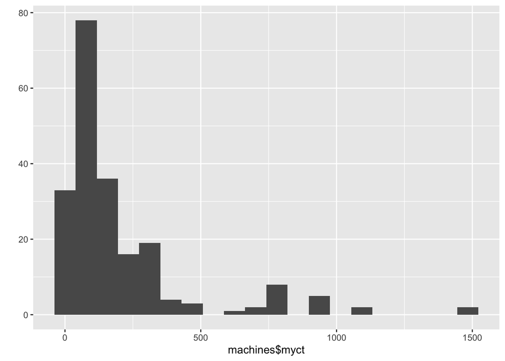

```r
qplot(machines$myct, bins=20)
```

## we see that there is less machines with higher cycle times as compared to those machines with low cycle times, this is expected as the general consumer of a machine doesn’t need a high end machine most of the time, due to other factors like cost.

## Saving the first 20 records of the machines data set as a data frame with name Machines_A and producing a summary

```r
Machines_A<-as.data.frame(machines[1:20,])
summary(Machines_A)
```

```
##      vend              model                myct             mmin
##  Length:20          Length:20          Min.   : 23.00   Min.   :   64
##  Class :character   Class :character   1st Qu.: 28.25   1st Qu.:  521
##  Mode  :character   Mode  :character   Median : 55.00   Median : 4500
##                                        Mean   :119.10   Mean   : 6769
##                                        3rd Qu.:149.00   3rd Qu.: 8000
##                                        Max.   :400.00   Max.   :32000
##       mmax            cach            chmin           chmax
##  Min.   :   64   Min.   :  0.00   Min.   : 1.00   Min.   :  2.00
##  1st Qu.: 4625   1st Qu.:  3.00   1st Qu.: 3.25   1st Qu.: 13.25
##  Median :16000   Median : 32.00   Median : 8.00   Median : 32.00
##  Mean   :20128   Mean   : 52.60   Mean   : 8.45   Mean   : 30.95
##  3rd Qu.:32000   3rd Qu.: 64.25   3rd Qu.:10.00   3rd Qu.: 32.00
##  Max.   :64000   Max.   :256.00   Max.   :32.00   Max.   :128.00
##       prp               erp
##  Min.   :  10.00   Min.   :  15.00
##  1st Qu.:  37.25   1st Qu.:  27.75
##  Median : 135.00   Median : 128.00
##  Mean   : 224.80   Mean   : 232.00
##  3rd Qu.: 281.25   3rd Qu.: 262.25
##  Max.   :1144.00   Max.   :1238.00
```

##Generating a new column with min and max main memories and adding the column to the Machines_A dataframe

```r
MinMaxMemo<-""
MinMaxMemo[Machines_A$mmin <=33000]<- "low"
MinMaxMemo[Machines_A$mmax >33000]<- "high"
```

```r
Machines_New <- data.frame(Machines_A,MinMaxMemo)
head(Machines_New)
```

```
##      vend   model myct mmin  mmax cach chmin chmax prp erp MinMaxMemo
## 1 adviser   32/60  125  256  6000  256    16   128 198 199        low
## 2  amdahl  470v/7   29 8000 32000   32     8    32 269 253        low
## 3  amdahl 470v/7a   29 8000 32000   32     8    32 220 253        low
## 4  amdahl 470v/7b   29 8000 32000   32     8    32 172 253        low
## 5  amdahl 470v/7c   29 8000 16000   32     8    16 132 132        low
## 6  amdahl  470v/b   26 8000 32000   64     8    32 318 290        low
```

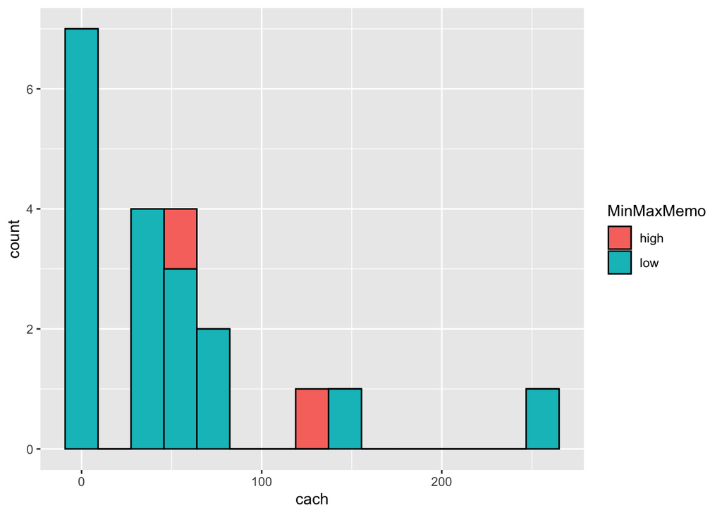

```r
ggplot(data = Machines_New, aes(x = cach)) +
  geom_histogram(aes(fill = MinMaxMemo),bins = 15,color = "black")
```

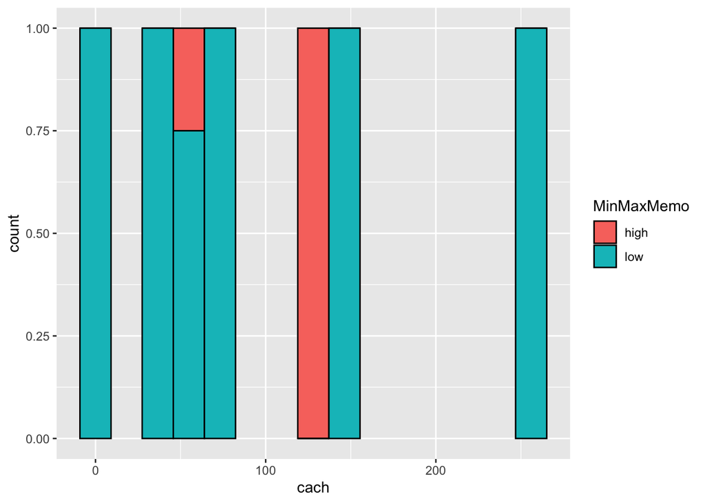

```r
ggplot(data = Machines_New, aes(x = cach)) +
  geom_histogram(aes(fill = MinMaxMemo),bins = 15,color = "black", position="fill")
```

##Based on the distribution, we see that most machines with high main memory also have high cache memory, Although having missing values, It is logical to conclude that that is the case.

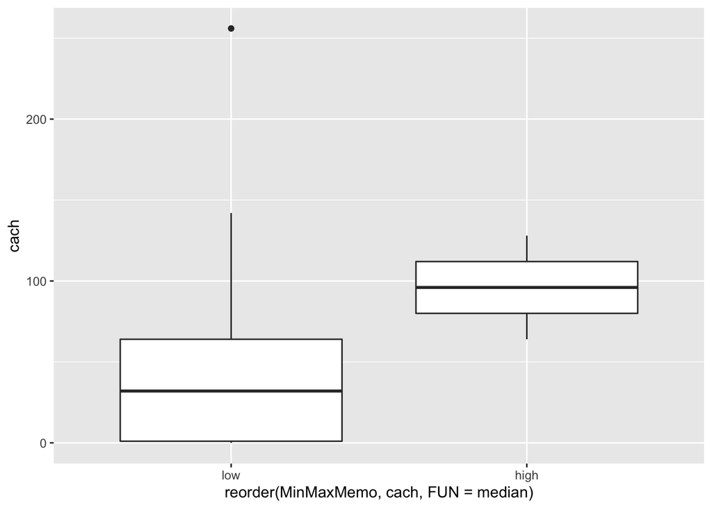

```r
ggplot(data = Machines_New) +
  geom_boxplot(mapping = aes(x = reorder(MinMaxMemo,cach , FUN = median), y = cach))
```

## The overlay boxplot shows that machines with high main memory have a higher cach memory unlike those machines with low cach memory.

# Missing Values

```r
colSums(is.na(machines))
```

```
##  vend model  myct  mmin  mmax  cach chmin chmax   prp   erp
##     0     0     0     0     0     0     0     0     0     0
```

> These is no missing value

## Hypothesis Testing

**We are trying to do Hypothesis testing on Published Relative Performance and Estimated Relative Performance, to check if there is any difference between these two features**

> We are doing EDA on the published and relative performances of all the machines.

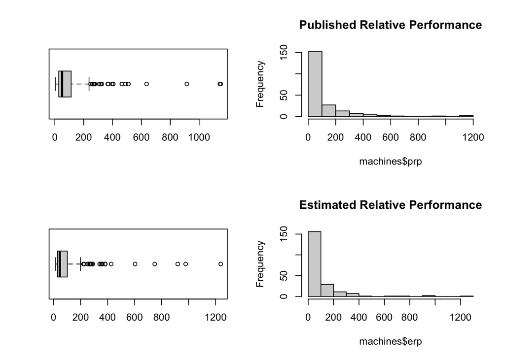

```r
par(mfrow = c(2,2))
boxplot(machines$prp, horizontal = TRUE)
hist(machines$prp, main = "Published Relative Performance")
boxplot(machines$erp, horizontal = TRUE)
hist(machines$erp, main = "Estimated Relative Performance")
```

> We want to compare the published and relative performance of IBM machines through hypothesis testing We want to compare the performances of IBM machines. This can be done by performing a test of difference in means assuming the sample is approximately from a normal distribution.

```r
ibm_dt <- machines[machines$vend == "ibm",]
```

> We should do f-test to compare mean, as we dont know the variance. We can conduct an f-test first to see if they have same variance. NUll Hypo: **ibm_prp/ibm_erp = 1** Alt Hypo: **ibm_prp/ibm_erp ≠ 1**. Confidence interval = 95%

```r
var.test(ibm_dt$prp, ibm_dt$erp, conf.level = 0.95)
```

```
##
##  F test to compare two variances
##
## data:  ibm_dt$prp and ibm_dt$erp
## F = 1.8341, num df = 31, denom df = 31, p-value = 0.0964
## alternative hypothesis: true ratio of variances is not equal to 1
## 95 percent confidence interval:
##  0.895313 3.757350
## sample estimates:
## ratio of variances
##           1.834122
```

> We can do t-test now to check if the mean is different. Null Hypo : **ibm_prp-ibm_erp = 0** Alt Hypo: **ibm_prp-ibm_erp ≠ 0**. Confidence interval = 95%

```r
t.test(ibm_dt$prp, ibm_dt$erp, var.equal = TRUE)
```

```
##
##  Two Sample t-test
##
## data:  ibm_dt$prp and ibm_dt$erp
## t = 0.50613, df = 62, p-value = 0.6146
## alternative hypothesis: true difference in means is not equal to 0
## 95 percent confidence interval:
##  -39.26588  65.89088
## sample estimates:
## mean of x mean of y
##  85.09375  71.78125
```

> As p-value > 0.05, we failed to reject Null Hypothesis. The published and estimated performances of ibm machines are same.

## Linear Regression

> Simple linear regression between machine cycle time and published relative performance

```r
fitlm <- lm(prp ~ myct, data = machines)
summary(fitlm)
```

```
##
## Call:
## lm(formula = prp ~ myct, data = machines)
##
## Residuals:
##     Min      1Q  Median      3Q     Max
## -116.67  -80.81  -47.21   21.52 1011.39
##
## Coefficients:
##              Estimate Std. Error t value Pr(>|t|)
## (Intercept) 144.30223   13.49236  10.695  < 2e-16 ***
## myct         -0.18977    0.04088  -4.643  6.1e-06 ***
## ---
## Signif. codes:  0 '***' 0.001 '**' 0.01 '*' 0.05 '.' 0.1 ' ' 1
##
## Residual standard error: 153.4 on 207 degrees of freedom
## Multiple R-squared:  0.09431,    Adjusted R-squared:  0.08993
## F-statistic: 21.56 on 1 and 207 DF,  p-value: 6.102e-06
```

```r
new <- data.frame(myct = 98)
predict(fitlm,new)
```

```
##        1
## 125.7044
```

> Confidence interval

```r
predict(fitlm, new, interval = "confidence")
```

```
##        fit      lwr      upr
## 1 125.7044 103.1102 148.2987
```

> Prediction Interval

```r
predict(fitlm, new, interval = "prediction")
```

```
##        fit       lwr      upr
## 1 125.7044 -177.6206 429.0294
```

> plot

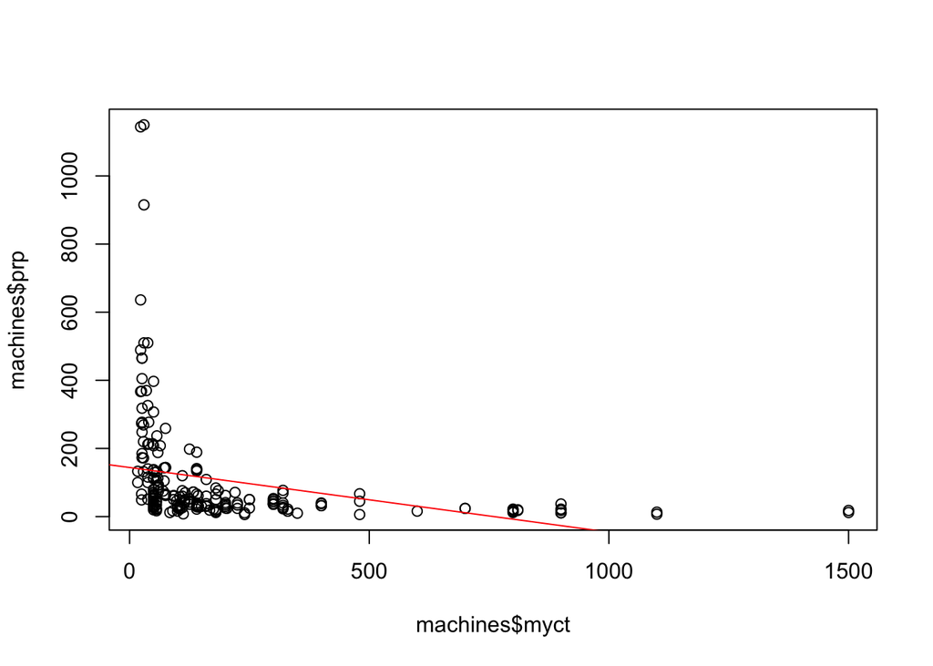

```r
plot(machines$myct,machines$prp)
abline(fitlm, col="red")
```

> diagnostic plots

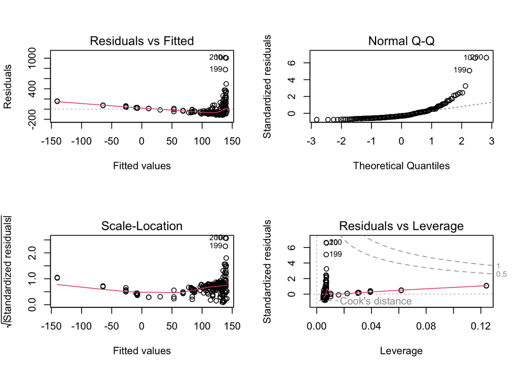

```r
par(mfrow=c(2,2))
plot(fitlm)
```

> Multiple Linear Regression

```r
mach_numeric <- subset(machines, select = -c(vend,model)) # categorical attributes dropped
#Splitting dataset
i <- sample(2, nrow(mach_numeric), replace = TRUE, prob = c(0.8,0.2))
mach_train <- mach_numeric[i==1,]
mach_test<- mach_numeric[i == 2,]
```

> Correlation

```r
cor(mach_train)
```

```
##             myct       mmin       mmax       cach      chmin      chmax
## myct   1.0000000 -0.3544336 -0.3770538 -0.3249533 -0.2755584 -0.2301699
## mmin  -0.3544336  1.0000000  0.7241296  0.5262310  0.4458110  0.2183823
## mmax  -0.3770538  0.7241296  1.0000000  0.5047127  0.4950595  0.5132712
## cach  -0.3249533  0.5262310  0.5047127  1.0000000  0.5485571  0.4727050
## chmin -0.2755584  0.4458110  0.4950595  0.5485571  1.0000000  0.5287690
## chmax -0.2301699  0.2183823  0.5132712  0.4727050  0.5287690  1.0000000
## prp   -0.3174502  0.7284886  0.8548744  0.6529829  0.5524043  0.6189045
## erp   -0.3033548  0.7451949  0.9110008  0.6474152  0.5515649  0.6167014
##              prp        erp
## myct  -0.3174502 -0.3033548
## mmin   0.7284886  0.7451949
## mmax   0.8548744  0.9110008
## cach   0.6529829  0.6474152
## chmin  0.5524043  0.5515649
## chmax  0.6189045  0.6167014
## prp    1.0000000  0.9606473
## erp    0.9606473  1.0000000
```

> Multiple linear regression

```r
fitlml <- lm(prp~., data = mach_train)
summary(fitlml)
```

```
##
## Call:
## lm(formula = prp ~ ., data = mach_train)
##
## Residuals:
##      Min       1Q   Median       3Q      Max
## -160.448  -16.699   -1.345    9.031  234.097
##
## Coefficients:
##               Estimate Std. Error t value Pr(>|t|)
## (Intercept) 11.3832311  7.9818834   1.426   0.1558
## myct        -0.0180170  0.0148156  -1.216   0.2258
## mmin         0.0025510  0.0016789   1.519   0.1306
## mmax        -0.0017417  0.0007667  -2.272   0.0244 *
## cach         0.0559861  0.1153357   0.485   0.6281
## chmin        0.1368594  0.6530984   0.210   0.8343
## chmax        0.2713133  0.1815156   1.495   0.1370
## erp          1.0657209  0.0781225  13.642   <2e-16 ***
## ---
## Signif. codes:  0 '***' 0.001 '**' 0.01 '*' 0.05 '.' 0.1 ' ' 1
##
## Residual standard error: 42.21 on 158 degrees of freedom
## Multiple R-squared:  0.9289, Adjusted R-squared:  0.9258
## F-statistic: 294.9 on 7 and 158 DF,  p-value: < 2.2e-16
```

> Plot

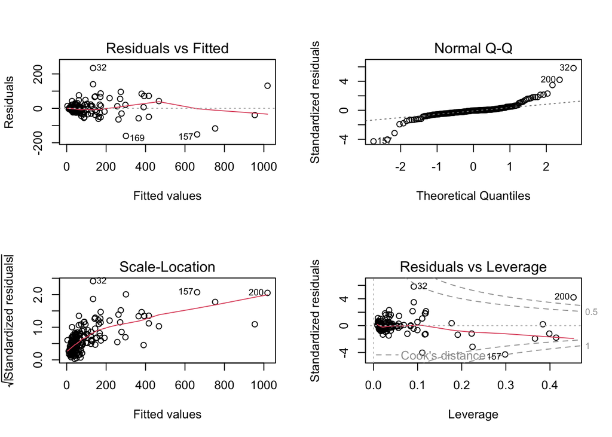

```r
par(mfrow = c(2,2))
plot(fitlml)
```

>Prediction

```r
library("Metrics")
ypredct <- predict(object = fitlml, newdata = mach_test)
summary(ypredct)
```

```
##     Min.  1st Qu.   Median     Mean  3rd Qu.     Max.
##    3.758   32.817   47.110  112.051   96.250 1329.403
```

```r
mae(mach_test$prp, ypredct)
```

```
## [1] 24.1687
```

```r
mse(mach_test$prp, ypredct)
```

```
## [1] 1576.557
```

> Forward stepwise regression

```r
library(MASS)
# create null model
intercpt_only <- lm(prp ~ 1, data = mach_train)
#create full model
all <- lm(prp~., data = mach_train)
# perform forward stepwise regression
forwrd <- stepAIC (intercpt_only, direction = 'forward', scope = formula(all))
```

```
## Start:  AIC=1675.2
## prp ~ 1
##
##         Df Sum of Sq     RSS    AIC
## + erp    1   3653578  305467 1251.9
## + mmax   1   2893311 1065734 1459.3
## + mmin   1   2101048 1857997 1551.6
## + cach   1   1688084 2270961 1584.9
## + chmax  1   1516484 2442561 1597.0
## + chmin  1   1208105 2750940 1616.8
## + myct   1    398971 3560074 1659.6
## <none>               3959045 1675.2
##
## Step:  AIC=1251.92
## prp ~ erp
##
##         Df Sum of Sq    RSS    AIC
## + mmax   1    9570.0 295897 1248.6
## + cach   1    6569.2 298898 1250.3
## + chmax  1    4477.1 300990 1251.5
## <none>               305467 1251.9
## + myct   1    2955.1 302512 1252.3
## + chmin  1    2892.1 302575 1252.3
## + mmin   1    1417.7 304049 1253.2
##
## Step:  AIC=1248.64
## prp ~ erp + mmax
##
##         Df Sum of Sq    RSS    AIC
## + myct   1    6752.2 289145 1246.8
## <none>               295897 1248.6
## + cach   1    3213.3 292684 1248.8
## + mmin   1    2969.6 292927 1249.0
## + chmax  1    2796.0 293101 1249.1
## + chmin  1    2671.0 293226 1249.1
##
## Step:  AIC=1246.81
## prp ~ erp + mmax + myct
##
##         Df Sum of Sq    RSS    AIC
## <none>               289145 1246.8
## + chmax  1    2013.3 287132 1247.7
## + mmin   1    1705.8 287439 1247.8
## + chmin  1    1605.2 287540 1247.9
## + cach   1    1311.9 287833 1248.0
```

> final model

```r
summary(forwrd)
```

```
##
## Call:
## lm(formula = prp ~ erp + mmax + myct, data = mach_train)
##
## Residuals:
##      Min       1Q   Median       3Q      Max
## -160.843  -18.576   -3.163   10.147  234.558
##
## Coefficients:
##               Estimate Std. Error t value Pr(>|t|)
## (Intercept) 19.8890635  6.7032703   2.967  0.00346 **
## erp          1.1699922  0.0560942  20.858  < 2e-16 ***
## mmax        -0.0019492  0.0007123  -2.737  0.00690 **
## myct        -0.0271716  0.0139698  -1.945  0.05350 .
## ---
## Signif. codes:  0 '***' 0.001 '**' 0.01 '*' 0.05 '.' 0.1 ' ' 1
##
## Residual standard error: 42.25 on 162 degrees of freedom
## Multiple R-squared:  0.927,  Adjusted R-squared:  0.9256
## F-statistic: 685.4 on 3 and 162 DF,  p-value: < 2.2e-16
```

> Checking MAE and MSE

```r
valfrwrd <- predict(object = forwrd, newdata = mach_test)
mae(mach_test$prp, valfrwrd)
```

```
## [1] 25.0892
```

```r
mse(mach_test$prp, valfrwrd)
```

```
## [1] 1700.185
```

> Backward stepwise selection

```r
backward <- stepAIC(all, direction = 'backward')
```

```
## Start:  AIC=1250.35
## prp ~ myct + mmin + mmax + cach + chmin + chmax + erp
##
##         Df Sum of Sq    RSS    AIC
## - chmin  1        78 281561 1248.4
## - cach   1       420 281903 1248.6
## - myct   1      2635 284117 1249.9
## <none>               281483 1250.3
## - chmax  1      3980 285463 1250.7
## - mmin   1      4113 285596 1250.8
## - mmax   1      9195 290677 1253.7
## - erp    1    331535 613018 1377.5
##
## Step:  AIC=1248.4
## prp ~ myct + mmin + mmax + cach + chmax + erp
##
##         Df Sum of Sq    RSS    AIC
## - cach   1       552 282113 1246.7
## - myct   1      2650 284211 1248.0
## <none>               281561 1248.4
## - mmin   1      4448 286009 1249.0
## - chmax  1      4833 286394 1249.2
## - mmax   1      9123 290684 1251.7
## - erp    1    332200 613761 1375.8
##
## Step:  AIC=1246.72
## prp ~ myct + mmin + mmax + chmax + erp
##
##         Df Sum of Sq    RSS    AIC
## - myct   1      3381 285494 1246.7
## <none>               282113 1246.7
## - mmin   1      5018 287132 1247.7
## - chmax  1      5326 287439 1247.8
## - mmax   1     11934 294047 1251.6
## - erp    1    407736 689849 1393.2
##
## Step:  AIC=1246.7
## prp ~ mmin + mmax + chmax + erp
##
##         Df Sum of Sq    RSS    AIC
## <none>               285494 1246.7
## - chmax  1      7434 292927 1249.0
## - mmin   1      7607 293101 1249.1
## - mmax   1      9567 295060 1250.2
## - erp    1    413220 698714 1393.3
```

> backward summary

```r
summary(backward)
```

```
##
## Call:
## lm(formula = prp ~ mmin + mmax + chmax + erp, data = mach_train)
##
## Residuals:
##      Min       1Q   Median       3Q      Max
## -153.318  -15.879   -5.683    8.199  246.041
##
## Coefficients:
##               Estimate Std. Error t value Pr(>|t|)
## (Intercept)  5.6960885  5.5736037   1.022   0.3083
## mmin         0.0032828  0.0015849   2.071   0.0399 *
## mmax        -0.0016218  0.0006982  -2.323   0.0214 *
## chmax        0.3418832  0.1669794   2.047   0.0422 *
## erp          1.0588864  0.0693656  15.265   <2e-16 ***
## ---
## Signif. codes:  0 '***' 0.001 '**' 0.01 '*' 0.05 '.' 0.1 ' ' 1
##
## Residual standard error: 42.11 on 161 degrees of freedom
## Multiple R-squared:  0.9279, Adjusted R-squared:  0.9261
## F-statistic: 517.9 on 4 and 161 DF,  p-value: < 2.2e-16
```

> MAE & MSE

```r
valbkwrd <- predict(object = backward, newdata = mach_test)
mae(mach_test$prp, valbkwrd)
```

```
## [1] 24.62795
```

```r
mse(mach_test$prp, valbkwrd)
```

```
## [1] 1668.696
```